# Data for predator-prey interaction

Shota Gugushvili

July 15, 2023

## Summary

This note deals with a real dataset describing the predator-prey interaction.

## Source

Data come from (Gause 1935). I extracted it by reading the point coordinates off Figure 3. To that end I used a handy tool called WebPlotDigitizer, see (Rohatgi 2022). Graphical quality of the original figure is modest, and I rounded off numbers to one digit after zero. Data are in principle daily, but for some reason days 12 and 14 did not appear in the graph. Perhaps Gause partied the night before and did not show up in the lab next morning.

Gause, G. F. 1935. “Experimental demonstration of Volterra’s periodic oscillations in the numbers of animals.” *Journal of Experimental Biology* 12 (1): 44–48. https://doi.org/10.1242/jeb.12.1.44.

Rohatgi, Ankit. 2022. “Webplotdigitizer: Version 4.6.” https://automeris.io/WebPlotDigitizer.

Gause presents, among others, results of an experiment on interaction of two species: *Paramecium aurelia* (predator) and *Saccharomyces exiguus* (prey). For details of the experiment, refer to the original paper. Being lab data obtained under controlled conditions, this dataset is not problematic to employ unlike the notorious and widely used Canadian lynx-hare dataset. You can download the latter, e.g., from Douglas Hundley’s page [here](http://people.whitman.edu/~hundledr/courses/M250F03/M250.html). Read also his comments on the dataset.

*Paramecium aurelia* is a protozoan.

*Saccharomyces exiguus* is a yeast.

The page was still functioning on July 15, 2023

## Preliminaries

Load packages and fix settings.

```r
## Packages

library(tidyverse) # Data manipulation

library(ggplot2) # Plotting
library(viridis) # Colour schemes
library(hrbrthemes) # Plotting themes

library(gauseR) # Some other predator-prey data

## Plot settings

# Fonts required for hrbrthemes:
# https://github.com/hrbrmstr/hrbrthemes/tree/master/inst/fonts/roboto-condensed

theme_set(hrbrthemes::theme_ipsum_rc(grid = "XY"))
```

## Data

Read in the data.

```r
gause_fig3 <- read_csv(file = "gause_fig3.csv") # Load data
glimpse(gause_fig3) # Quick check
```

```
## Rows: 36
## Columns: 3
## $ Time        <dbl> 0, 1, 2, 3, 4, 5, 6, 7, 8, 9, 10, 11, 13, 15, 16, 17, 18, …
## $ Species     <chr> "Saccharomyces exiguus", "Saccharomyces exiguus", "Sacchar…
## $ Individuals <dbl> 156.8, 39.3, 18.2, 8.3, 30.6, 57.4, 117.3, 109.3, 49.5, 18…
```

Data are in long format. The data frame contains three variables:

- `Time`: Day of the experiment
- `Species`: Names of the two species, `Paramecium aurelia` (predator) and `Saccharomyces exiguus` (prey)
- `Individuals`: Number of individuals

## Some plots

Data can be visualised in a single panel as below.

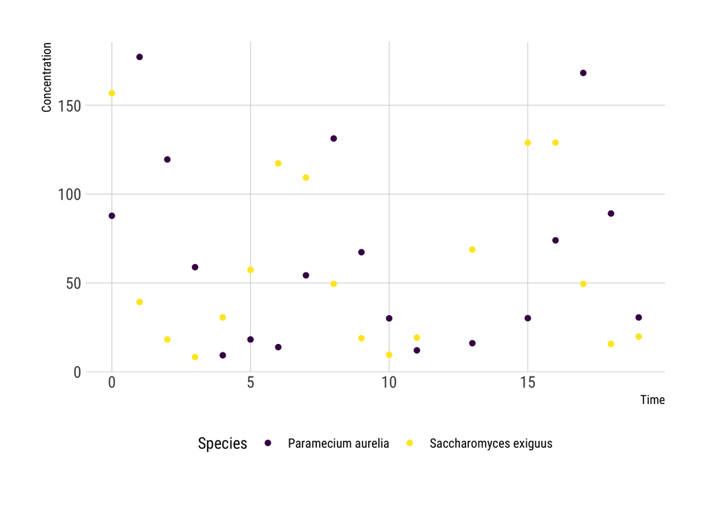

```r
# Plot with points

gause_fig3 %>%
  ggplot() +
  geom_point(aes(x = Time, y = Individuals, colour = Species)) +
  scale_color_viridis(discrete = TRUE) +
  theme(legend.position = "bottom") +
  ylab("Concentration") +
  xlab("Time")
```

You can also use lines instead of points. This looks rough due to low time resolution of the data, but simplifies seeing periodic patterns. Note the typical fluctuations, whose period is approximately constant. Gause remarks that the *Paramecium* mortality rate is somewhat high due to slight deficiency of oxygen in this experiment.

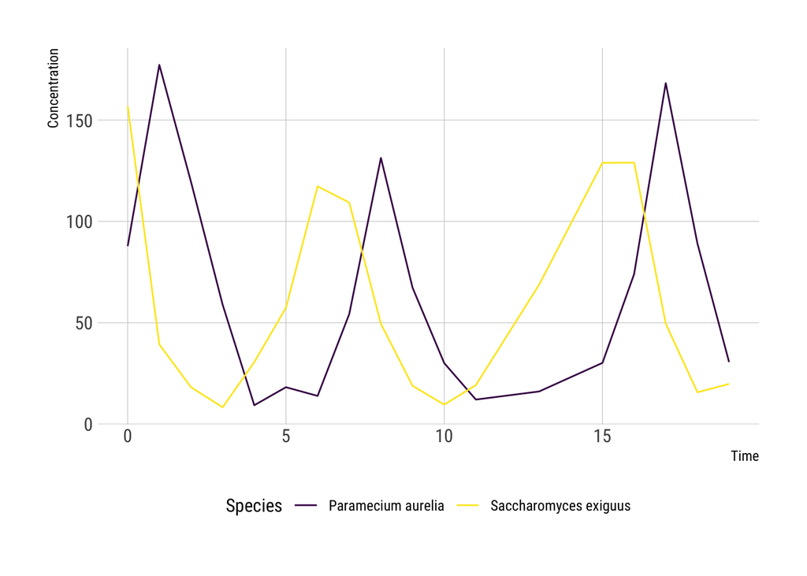

```r
# Plot with lines

gause_fig3 %>%
  ggplot() +
  geom_line(aes(x = Time, y = Individuals, colour = Species)) +
  scale_color_viridis(discrete = TRUE) +
  theme(legend.position = "bottom") +
  ylab("Concentration") +
  xlab("Time")
```

Facetting by species is a possibility too.

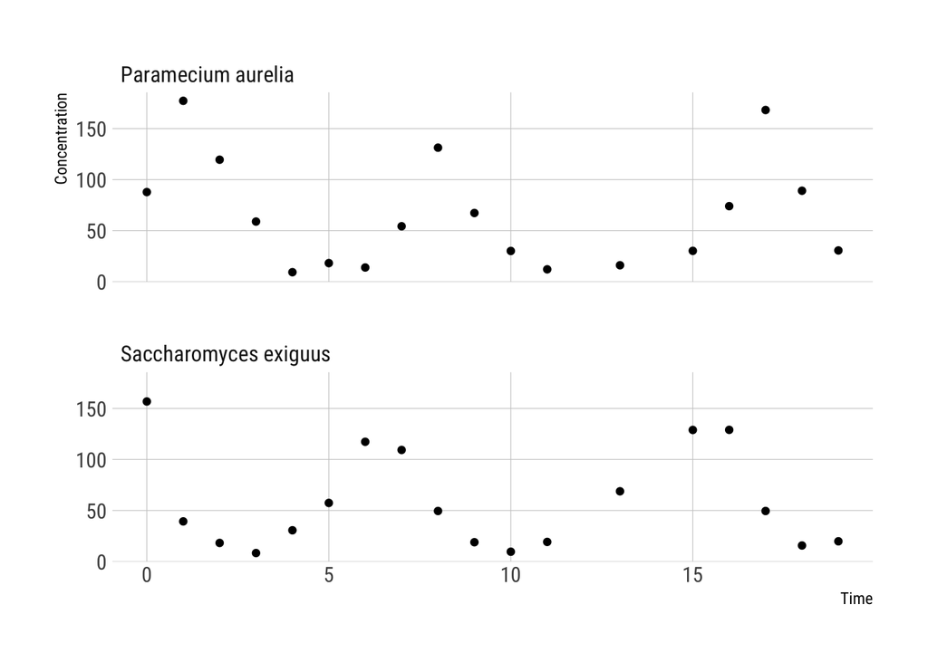

```r
## Points

gause_fig3 %>%
  ggplot() +
  geom_point(aes(x = Time, y = Individuals)) +
  facet_wrap(~ Species, nrow = 2) +
  ylab("Concentration") +
  xlab("Time")
```

Another option is to plot in the XY-plane the concentration of the predator against the concentration of the prey.

```r
# Convert data to wide format

gause_fig3_wide <- gause_fig3 %>%
  pivot_wider(names_from = Species, values_from = Individuals)

glimpse(gause_fig3_wide)
```

```
## Rows: 18
## Columns: 3
## $ Time                    <dbl> 0, 1, 2, 3, 4, 5, 6, 7, 8, 9, 10, 11, 13, 15, …
## $ `Saccharomyces exiguus` <dbl> 156.8, 39.3, 18.2, 8.3, 30.6, 57.4, 117.3, 109…
## $ `Paramecium aurelia`    <dbl> 87.8, 177.2, 119.5, 58.9, 9.3, 18.2, 13.9, 54.…
```

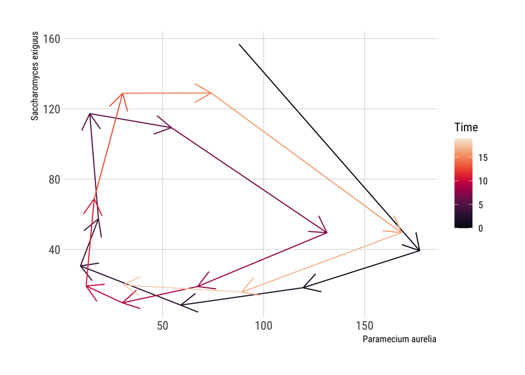

```r
gause_fig3_wide %>%
  ggplot() +
  geom_path(aes(y = `Saccharomyces exiguus`, x = `Paramecium aurelia`, colour = Time),
            arrow = arrow()) +
  scale_colour_viridis(option = "rocket") +
  xlab("Paramecium aurelia") +
  ylab("Saccharomyces exiguus")
```

Magnitude of fluctuations varies somewhat, but not too much. Things could have been worse when compared to Gause’s another experiment (that dataset is included the **gauseR** package).

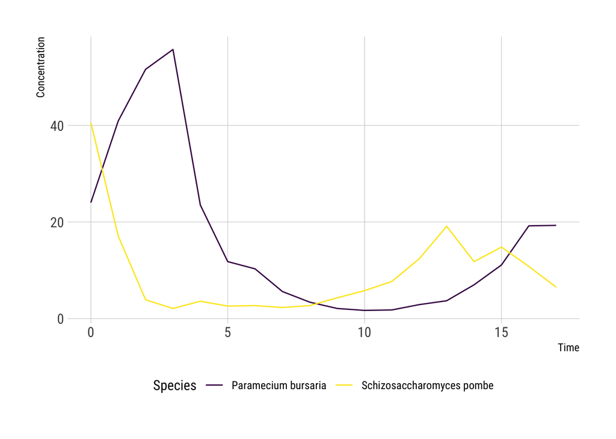

```r
gause_1934_book_f39.1 %>%
  ggplot() +
  geom_line(aes(x = Time, y = Individuals, colour = Species)) +
  scale_color_viridis(discrete = TRUE) +
  theme(legend.position = "bottom") +
  ylab("Concentration") +
  xlab("Time")
```

```r
gause_1934_book_f39.1_wide <- gause_1934_book_f39.1 %>%
  pivot_wider(names_from = Species, values_from = Individuals)

glimpse(gause_1934_book_f39.1_wide)
```

```
## Rows: 18
## Columns: 5
## $ Paper                       <fct> gause_1934_book, gause_1934_book, gause_19…
## $ Figure                      <dbl> 39.1, 39.1, 39.1, 39.1, 39.1, 39.1, 39.1, …
## $ Time                        <int> 0, 1, 2, 3, 4, 5, 6, 7, 8, 9, 10, 11, 12, …
## $ `Schizosaccharomyces pombe` <dbl> 40.6, 17.1, 3.9, 2.1, 3.6, 2.6, 2.7, 2.3, …
## $ `Paramecium bursaria`       <dbl> 24.0, 40.9, 51.6, 55.7, 23.5, 11.8, 10.3, …
```

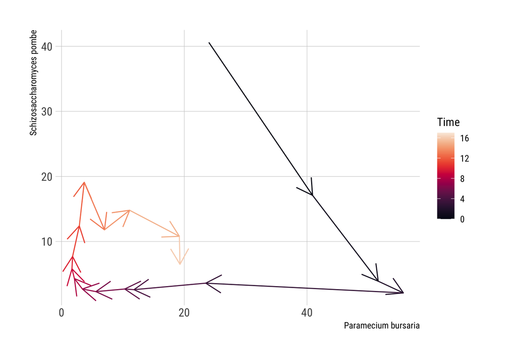

```r
gause_1934_book_f39.1_wide %>%
  ggplot() +
  geom_path(aes(y = `Schizosaccharomyces pombe`, x = `Paramecium bursaria`, colour = Time),
            arrow = arrow()) +
  scale_colour_viridis(option = "rocket") +
  xlab("Paramecium bursaria") +
  ylab("Schizosaccharomyces pombe")
```